# VIQ - Laboratorio 3

31 Marzo 2022

### Obiettivi

1. Apprendere le basi per la programmazione in R
2. Manipolare data set

### Strumento

R ed RStudio

### Dataset

Utilizziamo il dataset pubblico sugli omicidi tramite armi da fuoco negli USA per il 2010. Che è incluso nella libreria `dslabs` (da installare se non già presente) e da importare con la funzione `library()`.

Per poter usare il dataset è necessario utilizzare il comando `data(murders)` che include nell’environment il data frame omonimo con tutti i dati.

Le operazioni precedenti sono già compiute nel seguente *chunk*:

```r
if(! "dslabs" %in% installed.packages() ){
  install.packages("dslabs")
}
library(dslabs)

data(murders) # load the US murders dataset
```

Ulteriori informazioni possono essere ottenute (dopo aver importato il package) con il comando `? murders` o cercando `murders` nel pannello di help.

È possibile creare un data frame anche indicando esplicitamente i valori delle diverse colonne, usando la funzione `data.frame()`:

```r
temp <- c(35, 88, 42, 84, 81, 30)
city <- c("Beijing", "Lagos", "Paris",
          "Rio de Janeiro", "San Juan", "Toronto")
city_temps <- data.frame(name = city, temperature_F = temp)

# OPPURE:

city_temps2 <- data.frame(
  name = c("Beijing", "Lagos", "Paris", "Rio de Janeiro", "San Juan", "Toronto"),
  temperature_F = c(35, 88, 42, 84, 81, 30))
```

### Procedura

Per ogni parte di esercizio questo documento R-Markdown contiene un frammento (*chunk*) di codice R che deve essere completato secondo le indicazioni.

Dopo aver scritto il codice R è possibile verificare il funzionamento cliccando sulla freccia verde in alto a sinistra del blocco.

**Attenzione**: le varie parti degli esercizi possono dipendere da quelle precedenti e sicuramente dipendono dal blocco *setup* qui sopra che deve essere eseguito prima di tutti.

In alternativa è possibile utilizzare il pulsante in alto nel pannello dell’editor: il comando esegue tutti i *chunk*, inserisce il risultato nel documento e genera il file HTML.

## ESERCIZIO 1 - Uso dei data frame

### Data frames

I data frame (`data.frame`) sono lo strumento base in cui vengono memorizzati dati in formato tabulare provenienti da diverse fonti.

Buona parte delle elaborazioni ed analisi partono da dati memorizzati in data frame (o loro estensioni).

Stampare la porzione iniziale del dataset utilizzando la funzione `head()`

```r
# TODO: inserire il codice per stampare la porzione iniziale del dataset
head(murders, n = 1L)
```

```
##     state abb region population total
## 1 Alabama  AL  South    4779736   135
```

È possibile accedere alle singole colonne del dataframe utilizzando l’operatore di accesso `$` (o in alternativa quello di estrazione `[[]]` ), entrambi restituiscono un vettore.

Si ottenga il contenuto della colonna *abb* utilizzando i due operatori.

```r
## TODO scrivere il codice per ottenere il contenuto della colonna *abb* utilizzando i due operatori.

murders$abb
```

```
##  [1] "AL" "AK" "AZ" "AR" "CA" "CO" "CT" "DE" "DC" "FL" "GA" "HI" "ID" "IL" "IN"
## [16] "IA" "KS" "KY" "LA" "ME" "MD" "MA" "MI" "MN" "MS" "MO" "MT" "NE" "NV" "NH"
## [31] "NJ" "NM" "NY" "NC" "ND" "OH" "OK" "OR" "PA" "RI" "SC" "SD" "TN" "TX" "UT"
## [46] "VT" "VA" "WA" "WV" "WI" "WY"
```

```r
# OPPURE (dato che add = seconda colonnna)

murders[[2]]
```

```
##  [1] "AL" "AK" "AZ" "AR" "CA" "CO" "CT" "DE" "DC" "FL" "GA" "HI" "ID" "IL" "IN"
## [16] "IA" "KS" "KY" "LA" "ME" "MD" "MA" "MI" "MN" "MS" "MO" "MT" "NE" "NV" "NH"
## [31] "NJ" "NM" "NY" "NC" "ND" "OH" "OK" "OR" "PA" "RI" "SC" "SD" "TN" "TX" "UT"
## [46] "VT" "VA" "WA" "WV" "WI" "WY"
```

```r
# OPPURE

murders[["abb"]]
```

```
##  [1] "AL" "AK" "AZ" "AR" "CA" "CO" "CT" "DE" "DC" "FL" "GA" "HI" "ID" "IL" "IN"
## [16] "IA" "KS" "KY" "LA" "ME" "MD" "MA" "MI" "MN" "MS" "MO" "MT" "NE" "NV" "NH"
## [31] "NJ" "NM" "NY" "NC" "ND" "OH" "OK" "OR" "PA" "RI" "SC" "SD" "TN" "TX" "UT"
## [46] "VT" "VA" "WA" "WV" "WI" "WY"
```

Per capire quali sono i tipi di dato delle 5 colonne è possibile usare la funzione `class()` applicata alle singole colonne.

```r
# TODO: inserire il codice per ottenere il tipo delle colonne e poi avere il sommario del data.frame

class(murders$state)
```

```
## [1] "character"
```

```r
class(murders$abb)
```

```
## [1] "character"
```

```r
class(murders$region)
```

```
## [1] "factor"
```

```r
class(murders$population)
```

```
## [1] "numeric"
```

```r
class(murders$total)
```

```
## [1] "numeric"
```

La colonna *region* a differenza delle due precedenti ha come tipo `factor`. Dato un fattore è possibile conoscere i livelli (ovvero i possibili valori) tramite la funzione `levels()`.

Si stampino i livelli della colonna *regione*, ed il minimo e il massimo del numero di omicidi (colonna *total*).

```r
# TODO: stampare i livelli della colonna *regione* ed il minimo e massimo del numero di omicidi (colonna *total*).

levels(murders$region)
```

```
## [1] "Northeast"     "South"         "North Central" "West"
```

```r
min(murders$total)
```

```
## [1] 2
```

```r
max(murders$total)
```

```
## [1] 1257
```

```r
indicatore <- murders$region == "South" # mi rende un vettore di TRUE o FALSE
murders[indicatore, ]
```

```
##                   state abb region population total
## 1               Alabama  AL  South    4779736   135
## 4              Arkansas  AR  South    2915918    93
## 8              Delaware  DE  South     897934    38
## 9  District of Columbia  DC  South     601723    99
## 10              Florida  FL  South   19687653   669
## 11              Georgia  GA  South    9920000   376
## 18             Kentucky  KY  South    4339367   116
## 19            Louisiana  LA  South    4533372   351
## 21             Maryland  MD  South    5773552   293
## 25          Mississippi  MS  South    2967297   120
## 34       North Carolina  NC  South    9535483   286
## 37             Oklahoma  OK  South    3751351   111
## 41       South Carolina  SC  South    4625364   207
## 43            Tennessee  TN  South    6346105   219
## 44                Texas  TX  South   25145561   805
## 47             Virginia  VA  South    8001024   250
## 49        West Virginia  WV  South    1852994    27
```

```r
righe <- which(murders$region == "South") # mi rende il numero della riga delle regioni sud
murders[righe, ] # , ] vuol dire "qualsiasi cosa" => mi stampa tutto della riga di murders
```

```
##                   state abb region population total
## 1               Alabama  AL  South    4779736   135
## 4              Arkansas  AR  South    2915918    93
## 8              Delaware  DE  South     897934    38
## 9  District of Columbia  DC  South     601723    99
## 10              Florida  FL  South   19687653   669
## 11              Georgia  GA  South    9920000   376
## 18             Kentucky  KY  South    4339367   116
## 19            Louisiana  LA  South    4533372   351
## 21             Maryland  MD  South    5773552   293
## 25          Mississippi  MS  South    2967297   120
## 34       North Carolina  NC  South    9535483   286
## 37             Oklahoma  OK  South    3751351   111
## 41       South Carolina  SC  South    4625364   207
## 43            Tennessee  TN  South    6346105   219
## 44                Texas  TX  South   25145561   805
## 47             Virginia  VA  South    8001024   250
## 49        West Virginia  WV  South    1852994    27
```

```r
for (i in levels(murders$region)){
  murders_filtrato <- subset(murders, region == i)
  cat(i, "\n\tmin: ", min(murders_filtrato$total),
      "\tmax: ", max(murders_filtrato$total), "\n")
}
```

```
## Northeast
##  min:  2     max:  517
## South
##  min:  27    max:  805
## North Central
##  min:  4     max:  413
## West
##  min:  5     max:  1257
```

```r
# FATTO MEGLIO:

risultato <- NULL

for (i in levels(murders$region)){
  murders_filtrato <- subset(murders, region == i)
  riga <- data.frame(
    Regione = i,
    Minimo = min(murders_filtrato$total),
    Massimo = max(murders_filtrato$total)
    )
  risultato <- rbind(risultato, riga)
}

risultato
```

```
##         Regione Minimo Massimo
## 1     Northeast      2     517
## 2         South     27     805
## 3 North Central      4     413
## 4          West      5    1257
```

```r
# FATTO ANCORA MEGLIO:

#murders_raggrupp <- group_by(murders, region)
#murders_sintesi <- summarize(murders_raggrupp,
#                             min = min(total),
#                             max = max(total))
#murders_sintesi

# FATTO SUPER MEGLIO:
#murders %>% group_by(region) %>%
#  summarize(min = min(total),
#            max = max(total))
```

Per effettuare il conteggio dei diversi valori di una colonna è possibile utilizzare la funzione `table()`

Contare le frequenze dei diversi livelli della colonna *region*.

```r
# TODO: inserire il codice per calcolare le frequenze dei livelli di region

table(murders$region)
```

```
##
##     Northeast         South North Central          West
##             9            17            12            13
```

Si contino le frequenze dei diversi livelli della colonna *region*, esprimendoli anche come proporzioni (frazioni la cui somma = 1) e come percentuale (somma = 100%).

```r
# TODO: inserire il codice per calcolare le frequenze dei livelli di region ed esprimerli anche in percentuale.

frequenza <- table(murders$region)
proporzione <- frequenza / sum(frequenza)
percentuale <- paste0( # concatena quel che ha dentro: paste0("Data", " Mat") -> "Data Mat"
  round(proporzione*100, 1),"%") # round arrotonda al decimale ", 1)"
names(percentuale) <- names(proporzione)

frequenza
```

```
##
##     Northeast         South North Central          West
##             9            17            12            13
```

```r
proporzione
```

```
##
##     Northeast         South North Central          West
##     0.1764706     0.3333333     0.2352941     0.2549020
```

```r
percentuale
```

```
##     Northeast         South North Central          West
##       "17.6%"       "33.3%"       "23.5%"       "25.5%"
```

Per avere una visione d’insieme è possibile utilizzare la funzione `summary()` che stampa, oltre al tipo della colonna, anche alcune informazioni di riepilogo.

```r
# TODO: inserire il codice per avere il sommario del data.frame murders

summary(murders)
```

```
##     state               abb                      region     population
##  Length:51          Length:51          Northeast    : 9   Min.   :  563626
##  Class :character   Class :character   South        :17   1st Qu.: 1696962
##  Mode  :character   Mode  :character   North Central:12   Median : 4339367
##                                        West         :13   Mean   : 6075769
##                                                           3rd Qu.: 6636084
##                                                           Max.   :37253956
##      total
##  Min.   :   2.0
##  1st Qu.:  24.5
##  Median :  97.0
##  Mean   : 184.4
##  3rd Qu.: 268.0
##  Max.   :1257.0
```

### Ordinamento

Ordinare la *“variabile”* (o colonna) *population* dal valore più piccolo al più grande

```r
# TODO: interire il codice necesario

sort(murders$population)
```

```
##  [1]   563626   601723   625741   672591   710231   814180   897934   989415
##  [9]  1052567  1316470  1328361  1360301  1567582  1826341  1852994  2059179
## [17]  2700551  2763885  2853118  2915918  2967297  3046355  3574097  3751351
## [25]  3831074  4339367  4533372  4625364  4779736  5029196  5303925  5686986
## [33]  5773552  5988927  6346105  6392017  6483802  6547629  6724540  8001024
## [41]  8791894  9535483  9883640  9920000 11536504 12702379 12830632 19378102
## [49] 19687653 25145561 37253956
```

```r
# TODO: interire il codice necesario

states_by_population <- murders$state[order(-murders$population)]
states_by_population
```

```
##  [1] "California"           "Texas"                "Florida"
##  [4] "New York"             "Illinois"             "Pennsylvania"
##  [7] "Ohio"                 "Georgia"              "Michigan"
## [10] "North Carolina"       "New Jersey"           "Virginia"
## [13] "Washington"           "Massachusetts"        "Indiana"
## [16] "Arizona"              "Tennessee"            "Missouri"
## [19] "Maryland"             "Wisconsin"            "Minnesota"
## [22] "Colorado"             "Alabama"              "South Carolina"
## [25] "Louisiana"            "Kentucky"             "Oregon"
## [28] "Oklahoma"             "Connecticut"          "Iowa"
## [31] "Mississippi"          "Arkansas"             "Kansas"
## [34] "Utah"                 "Nevada"               "New Mexico"
## [37] "West Virginia"        "Nebraska"             "Idaho"
## [40] "Hawaii"               "Maine"                "New Hampshire"
## [43] "Rhode Island"         "Montana"              "Delaware"
## [46] "South Dakota"         "Alaska"               "North Dakota"
## [49] "Vermont"              "District of Columbia" "Wyoming"
```

Infine ordinare l’intero data frame sulla base del numero di omicidi (*total*)

```r
# TODO: interire il codice necesario

data_by_murders <- murders[ order(murders$total), ]
data_by_murders
```

```
##                   state abb        region population total
## 46              Vermont  VT     Northeast     625741     2
## 35         North Dakota  ND North Central     672591     4
## 30        New Hampshire  NH     Northeast    1316470     5
## 51              Wyoming  WY          West     563626     5
## 12               Hawaii  HI          West    1360301     7
## 42         South Dakota  SD North Central     814180     8
## 20                Maine  ME     Northeast    1328361    11
## 13                Idaho  ID          West    1567582    12
## 27              Montana  MT          West     989415    12
## 40         Rhode Island  RI     Northeast    1052567    16
## 2                Alaska  AK          West     710231    19
## 16                 Iowa  IA North Central    3046355    21
## 45                 Utah  UT          West    2763885    22
## 49        West Virginia  WV         South    1852994    27
```

[output cut: 37 more lines]

## ESERCIZIO 2 - Operazioni sui data frame

### Aritmetica tra vettori

A partire dal data frame sulle temperature (`city_temps`), calcolare le temperature in Celsius a partire da quelle espresse in Fahrenheit.

La formula di conversione è:

$$C = \frac{5}{9} \cdot ( F - 32 )$$

```r
# TODO: interire il codice necesario
city_temps_C <- data.frame(
  Name = city_temps$name,
  Temperatura_C = round(5/9*(city_temps$temperature_F-32), 1)
)

city_temps_C
```

```
##             Name Temperatura_C
## 1        Beijing           1.7
## 2          Lagos          31.1
## 3          Paris           5.6
## 4 Rio de Janeiro          28.9
## 5       San Juan          27.2
## 6        Toronto          -1.1
```

Usando la stessa conversione aggiungere una colonna al data frame delle temperature con le temperature in Celcius. Può essere utile un arrotondamento?

Suggerimento: l’operatore di accesso permette anche di assegnare a nuove colonne.

```r
# TODO: interire il codice necesario

city_temps_t <- city_temps
city_temps_t$temperature_C <- round(5/9*(city_temps$temperature_F-32), 1) #OPPURE aggiungi: city_temps_C$Temperatura_C

city_temps_t
```

```
##             name temperature_F temperature_C
## 1        Beijing            35           1.7
## 2          Lagos            88          31.1
## 3          Paris            42           5.6
## 4 Rio de Janeiro            84          28.9
## 5       San Juan            81          27.2
## 6        Toronto            30          -1.1
```

Calcolare (ed aggiungere come nuova colonna *rate*) il tasso di omicidi ogni 100 000 persone nel data frame degli omicidi e mostrare il data frame aggiornato

```r
# TODO: interire il codice necesario

murders$rate <- round(murders$total / murders$population * 100000, 1)
murders
```

```
##                   state abb        region population total rate
## 1               Alabama  AL         South    4779736   135  2.8
## 2                Alaska  AK          West     710231    19  2.7
## 3               Arizona  AZ          West    6392017   232  3.6
## 4              Arkansas  AR         South    2915918    93  3.2
## 5            California  CA          West   37253956  1257  3.4
## 6              Colorado  CO          West    5029196    65  1.3
## 7           Connecticut  CT     Northeast    3574097    97  2.7
## 8              Delaware  DE         South     897934    38  4.2
## 9  District of Columbia  DC         South     601723    99 16.5
## 10              Florida  FL         South   19687653   669  3.4
## 11              Georgia  GA         South    9920000   376  3.8
## 12               Hawaii  HI          West    1360301     7  0.5
## 13                Idaho  ID          West    1567582    12  0.8
## 14             Illinois  IL North Central   12830632   364  2.8
```

[output cut: 37 more lines]

Qual’è la media del tasso di omicidi?

```r
# TODO: interire il codice necesario

mean(murders$rate)
```

```
## [1] 2.784314
```

È possibile utilizzare la funzione `fivenum()` per calcolare la sintesi in 5 numeri (minimo, 1^o quartile, mediana, 3^o quartile, massimo) dei dati di una colonna. Quali sono i 5 numeri che sintetizzano la colonna *rate*?

```r
# TODO: interire il codice necesario

fivenum(murders$rate)
```

```
## [1]  0.30  1.25  2.70  3.40 16.50
```

### Indicatori

Quanti sono gli stati in cui il tasso di omicidi è minore al primo quartile (calcolato qui sopra)?

```r
# TODO: interire il codice necesario

sum(murders$rate < fivenum(murders$rate)[2])
```

```
## [1] 13
```

Usando un vettore indicatore, selezionare la porzione del dataframe che corrisponde agli stati nel primo quartile per tasso di omicidi.

```r
# TODO: interire il codice necesario

indicatore_Q1 <- murders$rate < fivenum(murders$rate)[2]
murders[ indicatore_Q1, ]
```

```
##            state abb        region population total rate
## 12        Hawaii  HI          West    1360301     7  0.5
## 13         Idaho  ID          West    1567582    12  0.8
## 16          Iowa  IA North Central    3046355    21  0.7
## 20         Maine  ME     Northeast    1328361    11  0.8
## 24     Minnesota  MN North Central    5303925    53  1.0
## 27       Montana  MT          West     989415    12  1.2
## 30 New Hampshire  NH     Northeast    1316470     5  0.4
## 35  North Dakota  ND North Central     672591     4  0.6
## 38        Oregon  OR          West    3831074    36  0.9
## 42  South Dakota  SD North Central     814180     8  1.0
## 45          Utah  UT          West    2763885    22  0.8
## 46       Vermont  VT     Northeast     625741     2  0.3
## 51       Wyoming  WY          West     563626     5  0.9
```

```r
# OPPURE

subset(murders, rate < fivenum(murders$rate)[2])
```

```
##            state abb        region population total rate
## 12        Hawaii  HI          West    1360301     7  0.5
## 13         Idaho  ID          West    1567582    12  0.8
## 16          Iowa  IA North Central    3046355    21  0.7
## 20         Maine  ME     Northeast    1328361    11  0.8
## 24     Minnesota  MN North Central    5303925    53  1.0
## 27       Montana  MT          West     989415    12  1.2
## 30 New Hampshire  NH     Northeast    1316470     5  0.4
## 35  North Dakota  ND North Central     672591     4  0.6
## 38        Oregon  OR          West    3831074    36  0.9
## 42  South Dakota  SD North Central     814180     8  1.0
## 45          Utah  UT          West    2763885    22  0.8
## 46       Vermont  VT     Northeast     625741     2  0.3
## 51       Wyoming  WY          West     563626     5  0.9
```

Riportare i dati relativi agli stati nella regione `"West"` che si trovano nel primo quartile, sempre per tasso di omicidi.

Suggerimento: costruire un vettore indicatore combinando con operatori Logici le due condizioni

```r
# TODO: interire il codice necesario

indicatore_west <- murders$region == "West"
indicatore_composto <- indicatore_Q1 & indicatore_west
murders[indicatore_composto, ]
```

```
##      state abb region population total rate
## 12  Hawaii  HI   West    1360301     7  0.5
## 13   Idaho  ID   West    1567582    12  0.8
## 27 Montana  MT   West     989415    12  1.2
## 38  Oregon  OR   West    3831074    36  0.9
## 45    Utah  UT   West    2763885    22  0.8
## 51 Wyoming  WY   West     563626     5  0.9
```

```r
#OPPURE

subset(murders[ indicatore_Q1, ], region == "West")
```

```
##      state abb region population total rate
## 12  Hawaii  HI   West    1360301     7  0.5
## 13   Idaho  ID   West    1567582    12  0.8
## 27 Montana  MT   West     989415    12  1.2
## 38  Oregon  OR   West    3831074    36  0.9
## 45    Utah  UT   West    2763885    22  0.8
## 51 Wyoming  WY   West     563626     5  0.9
```

Usare l’operatore `%in%`per creare un vettore indicatore che indentifichi gli stati che hanno come abbreviazioni MA, ME, MI, MO, MU. E calcolare il numero di stati identificati.

```r
# TODO: interire il codice necesario

identificati <- murders$abb %in% c("MA", "ME", "MI", "MO", "MU")
sum(identificati)
```

```
## [1] 4
```

```r
murders[identificati & murders$state %in% c("MA", "ME", "MI", "MO", "MU"), ]
```

```
## [1] state      abb        region     population total      rate
## <0 righe> (o 0-length row.names)
```

```r
# OPPURE

subset(murders, abb == "MA" | abb == "ME" | abb == "MI" | abb == "MO" | abb == "MU")
```

```
##            state abb        region population total rate
## 20         Maine  ME     Northeast    1328361    11  0.8
## 22 Massachusetts  MA     Northeast    6547629   118  1.8
## 23      Michigan  MI North Central    9883640   413  4.2
## 26      Missouri  MO North Central    5988927   321  5.4
```

Usare lo stesso operatore per capire quali tra le abbreviazioni corrispondono ad abbreviazioni reali e riportarne l’elenco.

```r
# TODO: interire il codice necesario

reali <- c("MA", "ME", "MI", "MO", "MU") %in% murders$abb
c("MA", "ME", "MI", "MO", "MU")[reali]
```

```
## [1] "MA" "ME" "MI" "MO"
```

## Fattori

La funzione `cut()` permette di suddividere valori numerici in intervalli (dati gli estremi, inferiore escluso) ed associare un valore a ciuscun intervallo. Il risultato è un vettore di *factor*.

```r
## Esempio di uso di cut()
x <- runif(50,1,31) # 50 numeri casuali tra 0 e 31
rating <- cut(x, c(0,18,30,31),c("Ins","Suff","Lode"))
names(x) <- rating
x
```

```
##       Ins      Suff       Ins       Ins       Ins      Lode       Ins       Ins
## 14.097470 19.883691 16.682301  6.019257  4.537861 30.668209  7.587538 13.275564
##       Ins       Ins       Ins       Ins       Ins      Suff       Ins       Ins
##  4.605269  8.438074  6.575932  1.644475  2.065376 25.398117  5.220161 10.322552
##      Suff       Ins       Ins       Ins      Suff       Ins      Suff       Ins
## 27.882972  4.734185 16.776148 16.474044 28.033271  3.230987 26.625929  3.369738
##      Suff      Suff       Ins      Suff       Ins      Suff      Suff       Ins
## 19.666710 27.957759  7.971540 21.041482  5.449630 28.366058 22.077963  3.189257
##       Ins      Lode      Suff      Suff      Suff      Suff      Suff      Suff
##  4.533335 30.227706 29.762406 23.527816 23.096250 23.980570 25.547507 29.175734
##       Ins      Suff       Ins       Ins       Ins       Ins       Ins       Ins
## 16.682794 25.260639 17.881632  2.042167 10.490376  2.079397  3.548145 11.619564
##      Suff       Ins
## 18.356188 14.199718
```

Associare al tasso di omicidi un livello (basso, medio, alto) corrispondente agli intervalli (0,1], (1,3], (3,20], e aggiungere tale classificazione come nuova colonna *rating*.

```r
# TODO: interire il codice necesario

murders$rating <- cut(murders$rate , c(0, 1, 3, 20),c("Basso", "Medio", "Alto"))
murders
```

```
##                   state abb        region population total rate rating
## 1               Alabama  AL         South    4779736   135  2.8  Medio
## 2                Alaska  AK          West     710231    19  2.7  Medio
## 3               Arizona  AZ          West    6392017   232  3.6   Alto
## 4              Arkansas  AR         South    2915918    93  3.2   Alto
## 5            California  CA          West   37253956  1257  3.4   Alto
## 6              Colorado  CO          West    5029196    65  1.3  Medio
## 7           Connecticut  CT     Northeast    3574097    97  2.7  Medio
## 8              Delaware  DE         South     897934    38  4.2   Alto
## 9  District of Columbia  DC         South     601723    99 16.5   Alto
## 10              Florida  FL         South   19687653   669  3.4   Alto
## 11              Georgia  GA         South    9920000   376  3.8   Alto
## 12               Hawaii  HI          West    1360301     7  0.5  Basso
## 13                Idaho  ID          West    1567582    12  0.8  Basso
## 14             Illinois  IL North Central   12830632   364  2.8  Medio
```

[output cut: 37 more lines]

Calcolare le frequenze dei diversi rating:

```r
# TODO: interire il codice necesario

table(murders$rating)
```

```
##
## Basso Medio  Alto
##    12    20    19
```

## ESERCIZIO 3 - Funzioni

### Temperature

La formula per convertire una temperatura Fahrenheit in un Celsius è:

$$C = \frac{5}{9} \cdot ( F - 32 )$$

Scrivere la funzione `f_to_c()` che riceve una temperature °F e la converte in °C.

```r
# TODO: interire il codice necesario

f_to_c <- function(temp_F){
  round( 5/9 *( temp_F - 32), 1)
}
```

Verifica:

```r
if( exists("f_to_c") ){
  print( f_to_c(61) )
}
```

```
## [1] 16.1
```

La funzione è vettorizzata? Ovvero funziona se applicata ad un vettore invece che ad una singolo valore? Se non lo è modificarla in modo che lo sia.

Verifica:

```r
temperature <- c(82,61,32)
if( exists("f_to_c") ){
  print( f_to_c( temperature ) )
}
```

```
## [1] 27.8 16.1  0.0
```

Scrivere la funzione `c_to_f()` che faccia la conversione inversa.

```r
# TODO: interire il codice necesario

c_to_f <- function(c){
  round( 9/5 * c + 32, 1)
}
```

Verifica:

```r
temperature <- c(28,16,0)
if( exists("c_to_f") ){
  print( c_to_f( temperature ) )

  print( f_to_c( c_to_f( temperature ) ) )
}
```

```
## [1] 82.4 60.8 32.0
## [1] 28 16  0
```

Scrivere una funzione `temp_conv()` che riceve due parametri (opzionali) `f` e `c` che contengono i valori delle temperature rispettivamente in °F e °C e partendo dal valore fornito calcoli e stampi quello mancante.

Suggerimento: utilizzare dei valori di default `NA` per poter facilmente rilevare quale parametro non è passato.

```r
# TODO: interire il codice necesario

temp_conv <- function(c=NA, f=NA){
  if(is.na(c[1])){
    print( f_to_c( f ))
  }
  else if(is.na(f[1])){
    print( c_to_f( c ))
  }
}
```

Verifica:

```r
if(exists("temp_conv")){
  temp_conv( f=c(82))
  temp_conv( c=c(28))
}
```

```
## [1] 27.8
## [1] 82.4
```

Anche questa funzione è vettorizzata?

Suggerimento: quando si fa un test su un vettore, viene utilizzato un solo elemento e questo causa un *warning*. Per risolvere il problema è possibile fare il test su un solo elemento (ad es. il primo) oppure verificare che il test risulti vero su tutti gli elementi (funzione `all()`)

Verifica:

```r
if(exists("temp_conv")){
  temp_conv( f=c(82,61,32))
  temp_conv( c=c(28,16,0))
}
```

```
## [1] 27.8 16.1  0.0
## [1] 82.4 60.8 32.0
```

## Fibonacci

Scrivere una funzione successione_Fibonacci in grado, dato il parametro *n*, di restituire i primi n+1 numeri della serie come array. Esempio: se n=7, allora la funzione restituisce il vettore `[1, 1, 2, 3, 5, 8, 13, 21]`.

È possibile fare una soluzione Iterativa (basata su un ciclo che ad ogni iterazione calcola un nuovo elemento), oppure una Ricorsiva che richiama se stessa per calcolare i valori precedenti.

Provare a sviluppare entrambe.

```r
# TODO: interire il codice necesario

successione_Fibonacci_s <- function(n){

  Fibonacci <- numeric(n+1)

  if(n==0){
    Fibonacci[1] <- 1
  }

  if(n==1) {
    Fibonacci[1] <- 1
    Fibonacci[2] <- 1
  }

  if(n>1){
    Fibonacci[1] <- 1
    Fibonacci[2] <- 1
    for (i in 3:(n+1)) Fibonacci[i] <- Fibonacci[i - 2] + Fibonacci[i - 1]
  }

  return(Fibonacci)

}
```

Verifica:

```r
# specificare un intero n:
n <- 7
if( exists("successione_Fibonacci") ){
  print( successione_Fibonacci_s(n) )
}
```

Versione ricorsiva:

```r
# TODO: interire il codice necesario

successione_Fibonacci_r <- function(n) {

  if(n==0){
     return( 1 )
  }

  if(n==1) {
    return( c(1,1) )
  }

  if(n>1){
    precedenti = successione_Fibonacci(n-1)
    return( c( precedenti, sum(tail(precedenti,2)) ) )
  }
}
```

Verifica:

```r
# specificare un intero n:
n <- 7
if( exists("successione_Fibonacci") ){
  print( successione_Fibonacci_r(n) )
}
```

# ESERCIZIO 4 - Grafici di base

Utilizzare la funzione `plot()` per costruire un grafico a dispersione (scatterplot) che mostri la correlazione tra la popolazione ed il numero di omicidi

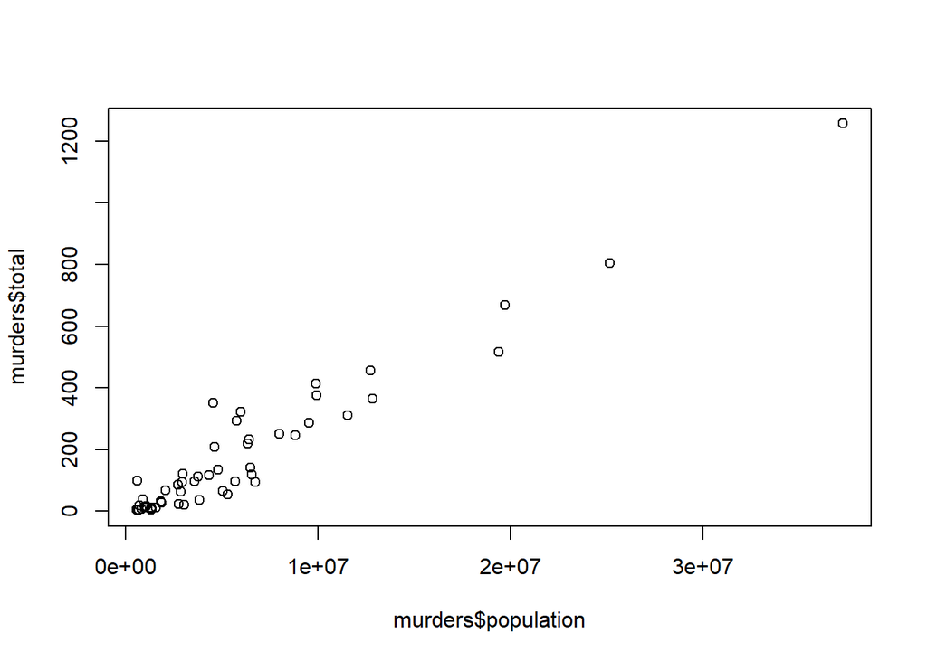

```r
# TODO: interire il codice necesario

plot(murders$population, murders$total)
```

Utilizzare la funzione `plot()` passando una formula (`~`) invece delle due colonne.

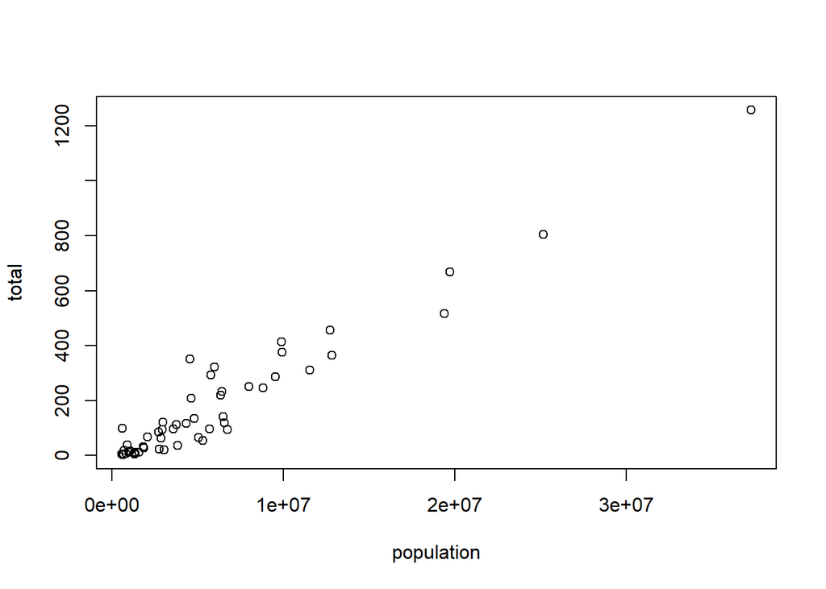

```r
# TODO: interire il codice necesario

plot(total ~ population, data=murders)
```

Utilizzare una scala logaritmica sui due assi in modo da distanziare tutti gli stati con popolazione molto bassa.

Suggerimento: è possibile utilizzare il parametro `log`, descritto come segue

> una stringa di caratteri che contiene “x” se l’asse x deve essere logaritmico, “y” se l’asse y deve essere logaritmico e “xy” o “yx” se entrambi gli assi devono essere logaritmici.

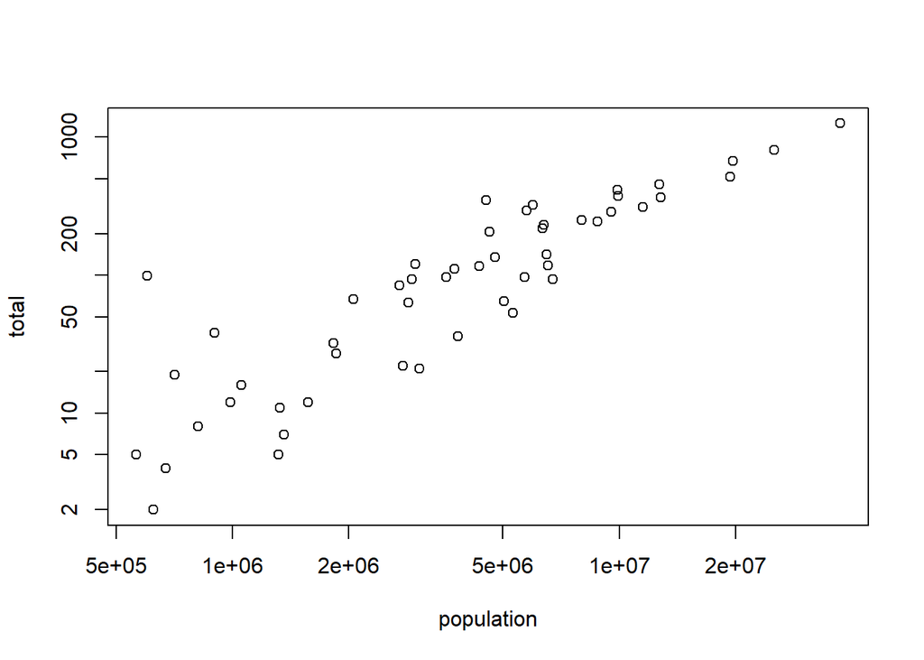

```r
# TODO: interire il codice necesario

plot(total ~ population, data=murders, log="xy")
```

Nota: il parametro `log` è descritto nel manuale della funzione `plot.default` che è richiamata da `plot`.

## Istogrammi

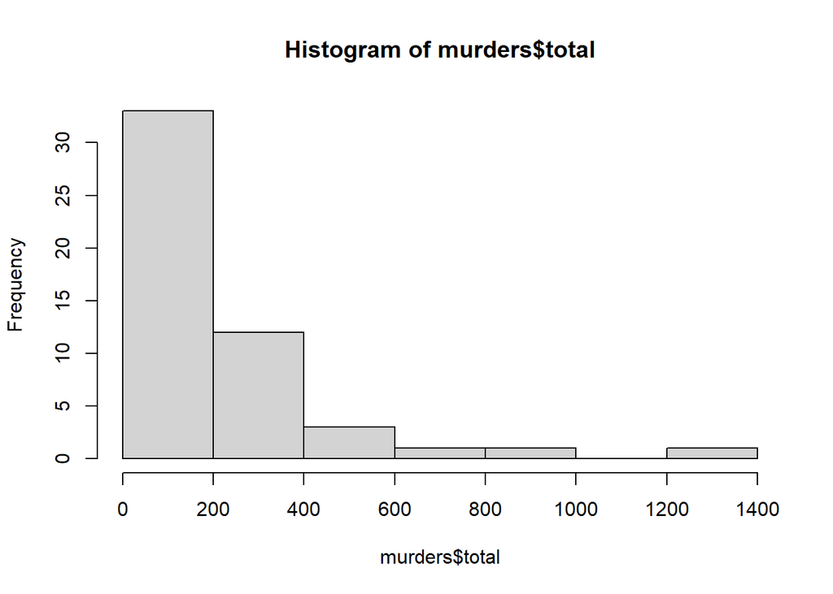

```r
# TODO: interire il codice necesario

hist(murders$total)
```

Utilizzare il parametro `breaks` che accetta un vettore con i limiti degli intervalli (*bin*) dell’istogramma in modo da utilizzare dei bin di ampiezza 1.

Suggerimento: utilizzare l’operatore range (`:`) per costruire il vettore con i limiti

```r
# TODO: interire il codice necesario
```

Come cambia l’istogramma se l’ampiezza dei *bin* è pari a 0.5?

```r
# TODO: interire il codice necesario
```

## Boxplots

Utilizzare un boxplot per rappresentare la distribuzione dei tassi di omicidio.

Suggerimento: si usi la funzione `boxplot()`, è inoltre possibile utilizzare il parametro `horizontal` per mostrare il boxplot in orizzontale.

```r
# TODO: interire il codice necesario
```

Mostrare il confronto tra le distribuzioni dei tassi di omicidio nelle diverse regioni.

Si usi la versione con la formula della funzione `boxplot()`

```r
# TODO: interire il codice necesario
```

Osservazione: le diverse regioni sono riportate secondo l’ordine dei livelli del tipo fattore: `levels(murders$region)`.

È possibile cambiare l’ordinamento dei livelli di un fattore tramite la funzione `reorder()` che riceve come parametri: - un vettore di fattori (o che viene convertito in fattore) - un vettore di pari lunghezza i cui valori sono utilizzati per riordinare i livelli - una funzione (opzionale) per aggregare i valori che corrispondono allo stesso livello

Ad esempio per ordinare le regioni in base alla popolazione totale:

```r
reorder(murders$region, murders$population, sum)
```

```
##  [1] South         West          West          South         West
##  [6] West          Northeast     South         South         South
## [11] South         West          West          North Central North Central
## [16] North Central North Central South         South         Northeast
## [21] South         Northeast     North Central North Central South
## [26] North Central West          North Central West          Northeast
## [31] Northeast     West          Northeast     South         North Central
## [36] North Central South         West          Northeast     Northeast
## [41] South         North Central South         South         West
## [46] Northeast     South         West          South         North Central
## [51] West
## attr(,"scores")
##     Northeast         South North Central          West
##      55317240     115674434      66927001      71945553
## Levels: Northeast North Central West South
```

La funzione `sum` viene utilizzata per calcolare un punteggio aggregato (*score*) che poi viene utilizzato per ri-ordinare i livelli.

Utilizzando la funzione `reorder()` si mostri un boxplot analogo a quello precedente ma con le regioni ordinate in base al valore medio (funzione `mean`) del tasso di omicidi.

```r
# TODO: interire il codice necesario
```

## Diagrammi a barre

Costruire un diagramma a barre, utilizzando la funzione `barplot()` che riporti il tasso di omicidi per i diversi stati (si usi l’abbreviazione abb).

Suggerimento: si usi la versione con la formula ed impostare - il parametro `horiz` a `TRUE` per avere le barre orizzontali - il parametro `las` a 1 per avere le etichette orizzontali

NB: sono stati impostati i parametri `fig.width` e `fig.height` del chunk per garantire un corretto rapporto altezza/larghezza

```r
# TODO: interire il codice necesario
```

Osservazione: le etichette (di tipo `character`) sono mostrate in ordine alfabetico con il primo elemento nella posizione più prossima all’asse orizzontale (quindi in basso).

Modificare il grafico precedente ordinando le barre per tasso decrescente dall’alto verso il basso.

Suggerimento: la funzione `reorder()` trasforma in fattore il primo parametro se questo non lo è, poi riordina i fattori.

```r
# TODO: interire il codice necesario
```